# AREC615 HW#1

Joey Blumberg

9/15/2020

## Part 1: Coding Practice

**Problem 1.**

```r
## a.

x <- seq(from = -1, to = 1, by = .1)
print(x)
```

```
##  [1] -1.0 -0.9 -0.8 -0.7 -0.6 -0.5 -0.4 -0.3 -0.2 -0.1  0.0  0.1  0.2  0.3  0.4
## [16]  0.5  0.6  0.7  0.8  0.9  1.0
```

```r
### i.

sin(x)
```

```
##  [1] -0.84147098 -0.78332691 -0.71735609 -0.64421769 -0.56464247 -0.47942554
##  [7] -0.38941834 -0.29552021 -0.19866933 -0.09983342  0.00000000  0.09983342
## [13]  0.19866933  0.29552021  0.38941834  0.47942554  0.56464247  0.64421769
## [19]  0.71735609  0.78332691  0.84147098
```

```r
### ii.

x^3
```

```
##  [1] -1.000 -0.729 -0.512 -0.343 -0.216 -0.125 -0.064 -0.027 -0.008 -0.001
## [11]  0.000  0.001  0.008  0.027  0.064  0.125  0.216  0.343  0.512  0.729
## [21]  1.000
```

```r
### iii.

cos(x)
```

```
##  [1] 0.5403023 0.6216100 0.6967067 0.7648422 0.8253356 0.8775826 0.9210610
##  [8] 0.9553365 0.9800666 0.9950042 1.0000000 0.9950042 0.9800666 0.9553365
## [15] 0.9210610 0.8775826 0.8253356 0.7648422 0.6967067 0.6216100 0.5403023
```

```r
### iv.

x^(.5)
```

```
##  [1]       NaN       NaN       NaN       NaN       NaN       NaN       NaN
##  [8]       NaN       NaN       NaN 0.0000000 0.3162278 0.4472136 0.5477226
## [15] 0.6324555 0.7071068 0.7745967 0.8366600 0.8944272 0.9486833 1.0000000
```

```r
### v.

log(x)
```

```
##  [1]        NaN        NaN        NaN        NaN        NaN        NaN
##  [7]        NaN        NaN        NaN        NaN       -Inf -2.3025851
## [13] -1.6094379 -1.2039728 -0.9162907 -0.6931472 -0.5108256 -0.3566749
## [19] -0.2231436 -0.1053605  0.0000000
```

```r
## b.

### i.

x <- c(2, 3, 4, 5)
y <- seq(from = -1, to = 2, by = 1)

### ii.

x^y
```

```
## [1]  0.5  1.0  4.0 25.0
```

```r
x * y
```

```
## [1] -2  0  4 10
```

```r
x %o% y # x %*% t(y)
```

```
##      [,1] [,2] [,3] [,4]
## [1,]   -2    0    2    4
## [2,]   -3    0    3    6
## [3,]   -4    0    4    8
## [4,]   -5    0    5   10
```

```r
x / y
```

```
## [1] -2.0  Inf  4.0  2.5
```

```r
## c.
```

R will perform element by element operations when using standard operators, for matrix operations you need to use matrix operators (%%)

**Problem 2.**

```r
rm(list = ls())

## a.

A <- matrix( runif(n = 100, min = 0, max = 1), nrow = 10, ncol = 10)
B <- matrix( runif(n = 100, min = 0, max = 1), nrow = 10, ncol = 10)

## b.

y <- matrix( runif(n = 10, min = 0, max = 1), nrow = 10, ncol = 1)

## c.

### i.

A - B
```

```
##              [,1]       [,2]        [,3]        [,4]        [,5]        [,6]
##  [1,]  0.22177410  0.2161699 -0.77507576  0.32026941  0.19822392  0.33805246
##  [2,]  0.12813777  0.7150172 -0.17024075 -0.44558353 -0.36210490 -0.28697741
##  [3,] -0.10769791  0.3999617  0.21939431  0.13383376 -0.08618107  0.86513532
##  [4,] -0.45370402 -0.5040405  0.10574335  0.57923142 -0.05139480 -0.36137618
##  [5,] -0.11413475  0.3172434  0.82923805 -0.41739466  0.58184459  0.59047946
##  [6,] -0.09578157  0.1367498 -0.73139484  0.14371964 -0.05852368 -0.20269602
##  [7,] -0.55382809  0.6753391 -0.64421540 -0.52599459  0.09573200 -0.07701128
##  [8,] -0.39287720  0.1880427  0.06429096  0.43325590  0.01905666 -0.63390915
##  [9,] -0.54468187 -0.1719341 -0.37932015 -0.04356494  0.61497462 -0.05228554
## [10,] -0.22173274 -0.2522665 -0.05197281  0.19323228  0.10037041 -0.19521334
##              [,7]         [,8]       [,9]        [,10]
##  [1,] -0.52685549 -0.374205521  0.7555507  0.382079555
##  [2,]  0.43022540  0.282323516 -0.7807418 -0.172498950
##  [3,] -0.26164328  0.358150789  0.2805300 -0.280981945
##  [4,] -0.03892188  0.265429527 -0.4419461  0.421762788
##  [5,] -0.12635309 -0.332715595 -0.3051355 -0.243445699
##  [6,] -0.28650988  0.220916050 -0.3446801  0.009772778
##  [7,]  0.42223341 -0.679928136 -0.6595693  0.447837700
##  [8,]  0.13544473 -0.041886072  0.1463909  0.140524903
##  [9,]  0.49821612 -0.026197518 -0.2950128  0.438427911
## [10,] -0.43933244 -0.003604148 -0.4176562  0.266993195
```

```r
### ii.

A + B
```

```
##            [,1]      [,2]      [,3]      [,4]      [,5]      [,6]      [,7]
##  [1,] 1.0720316 1.3126581 1.1686670 1.6078768 1.7720984 0.8194897 0.9433576
##  [2,] 0.6603137 0.7726544 0.3259826 0.5885214 0.8127647 0.8635268 0.6814763
##  [3,] 1.3447015 1.2523697 1.4173923 1.7777844 1.8140563 0.9405228 0.7187000
##  [4,] 1.4074863 1.3494986 1.7790659 1.3167258 1.8207613 1.4042039 0.8877196
##  [5,] 0.3863291 0.5013319 0.9392109 0.4197702 0.6678376 1.0606171 1.8529876
##  [6,] 0.2305503 0.9426354 1.0631516 0.5908389 1.2016303 0.2069933 1.5139491
##  [7,] 0.8121333 1.2461057 1.3544181 0.5480754 0.8459567 0.9598014 1.5628902
##  [8,] 1.1791131 1.1190720 1.4318991 1.4344602 1.3822780 1.0825429 1.0182427
##  [9,] 0.5498473 1.2653647 1.2812212 1.0900581 0.9808958 1.1402188 0.8038555
## [10,] 1.4621446 0.7843936 1.1637237 0.2507412 0.2311218 1.1668386 0.7740667
##            [,8]      [,9]     [,10]
##  [1,] 1.6028694 0.8808358 0.8177100
##  [2,] 1.4865496 0.9762588 1.7149603
##  [3,] 0.4170350 0.3329869 0.9918345
##  [4,] 0.6751668 1.2296762 1.1726808
##  [5,] 1.3933082 1.0685470 1.2611410
##  [6,] 0.3696708 0.6888220 0.3570198
##  [7,] 1.2552039 1.1273860 1.0429368
##  [8,] 0.1558889 0.5783505 0.1732374
##  [9,] 1.3714585 0.5329824 0.9365843
## [10,] 1.4381777 0.8650277 0.5898900
```

```r
### iii.

A * B
```

```
##              [,1]       [,2]       [,3]        [,4]       [,5]         [,6]
##  [1,] 0.275016989 0.41908548 0.19126001 0.620673803 0.77525998 0.1393209849
##  [2,] 0.104898740 0.02143630 0.01932068 0.036953192 0.13236661 0.1658306458
##  [3,] 0.449155845 0.35211515 0.49021680 0.785651449 0.82084330 0.0340310208
##  [4,] 0.443792582 0.39177245 0.78847348 0.349564424 0.82813255 0.4602989774
##  [5,] 0.034055863 0.03767258 0.04862035 0.000497172 0.02686598 0.1940606456
##  [6,] 0.010994838 0.21746526 0.14883823 0.082108821 0.36012260 0.0004401398
##  [7,] 0.088208745 0.27417409 0.35485871 0.005929081 0.17661953 0.2288219888
##  [8,] 0.308988777 0.30424051 0.51155041 0.467491358 0.47758230 0.1925145909
##  [9,] 0.001413419 0.39289661 0.37441098 0.296582163 0.14599070 0.3243412615
## [10,] 0.522175391 0.13790875 0.33788791 0.006383114 0.01083576 0.3308509898
##             [,7]        [,8]        [,9]       [,10]
##  [1,] 0.15308671 0.607290155 0.051253747 0.130666196
##  [2,] 0.06982902 0.532530819 0.085880866 0.727833208
##  [3,] 0.11201811 0.011411557 0.008045801 0.226196216
##  [4,] 0.19663279 0.096349334 0.329196828 0.299324090
##  [5,] 0.85439948 0.457652023 0.262171241 0.382802689
##  [6,] 0.55248852 0.021963154 0.088917835 0.031841905
##  [7,] 0.56608616 0.278308649 0.208991886 0.221789638
##  [8,] 0.25461824 0.005636726 0.078264740 0.002565989
##  [9,] 0.09949110 0.470053001 0.049259422 0.171242770
## [10,] 0.10154155 0.517085502 0.143459061 0.069171208
```

```r
### iv.

A %*% B  # Element-wise multiplication (*) vs Matrix multiplication (%*%)
```

```
##           [,1]     [,2]     [,3]     [,4]     [,5]     [,6]     [,7]     [,8]
##  [1,] 3.437384 2.922278 3.988494 2.771127 3.140339 3.335671 3.489652 3.462788
##  [2,] 2.369629 1.514246 2.655392 1.706383 1.959050 2.331557 2.127293 2.319990
##  [3,] 3.257912 2.691153 3.917728 2.914833 3.679594 2.762863 3.634153 2.871546
##  [4,] 3.734503 2.881701 3.999799 2.846195 3.376895 2.946536 3.643267 3.057281
##  [5,] 2.744803 1.885833 3.391129 2.432684 2.524185 2.095367 3.040501 2.529225
##  [6,] 1.677708 1.048379 1.708964 1.414154 1.372357 1.591038 1.554321 1.840585
##  [7,] 2.428095 1.452882 2.843632 2.002661 1.971983 2.216482 2.439167 2.847644
##  [8,] 2.734443 2.106441 3.025100 2.441950 2.781477 2.204709 2.570532 2.546939
##  [9,] 2.866692 1.927708 3.005245 2.077130 2.387897 2.546959 2.916937 2.456499
## [10,] 2.226692 1.765846 2.736374 1.841684 2.314156 1.785259 2.172227 1.712363
##           [,9]    [,10]
##  [1,] 3.540955 2.563795
##  [2,] 2.266419 1.412528
##  [3,] 3.287643 2.808910
##  [4,] 3.250485 2.575354
##  [5,] 2.618298 2.035254
##  [6,] 1.984324 1.457725
##  [7,] 2.945955 2.074422
##  [8,] 2.774433 2.383340
##  [9,] 2.975911 2.040037
## [10,] 1.509434 1.218750
```

```r
### v.

diag(A)
```

```
##  [1] 0.646902839 0.743835758 0.818393328 0.947978591 0.624841087 0.002148651
##  [7] 0.992561792 0.057001409 0.118984793 0.428441592
```

```r
## d.

C <- A * B

## e.

solve(C, y) # Returns vector x in the equation y = Cx
```

```
##             [,1]
##  [1,]  -4.717409
##  [2,] -12.412574
##  [3,]  12.980400
##  [4,]  -2.906846
##  [5,]   3.667949
##  [6,]  -4.469891
##  [7,]   1.249303
##  [8,]   6.877357
##  [9,]  -9.299544
## [10,]  -1.907442
```

**Problem 3.**

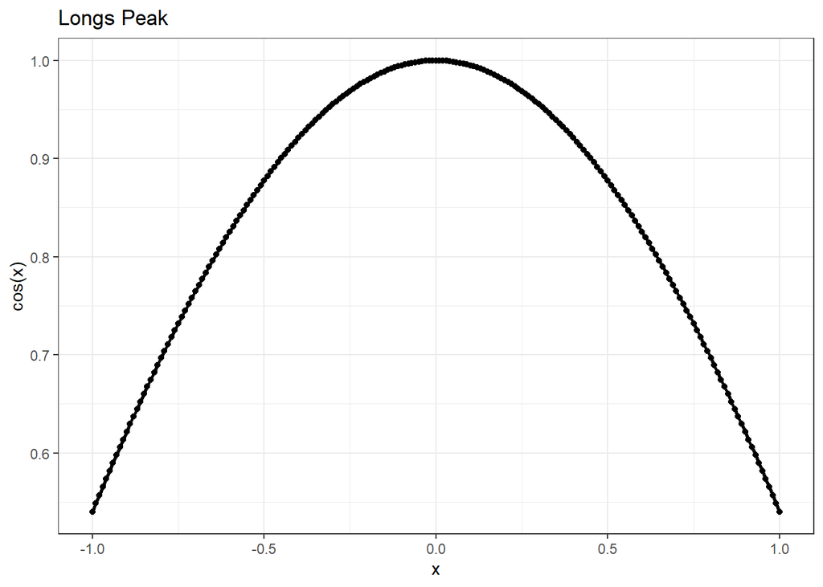

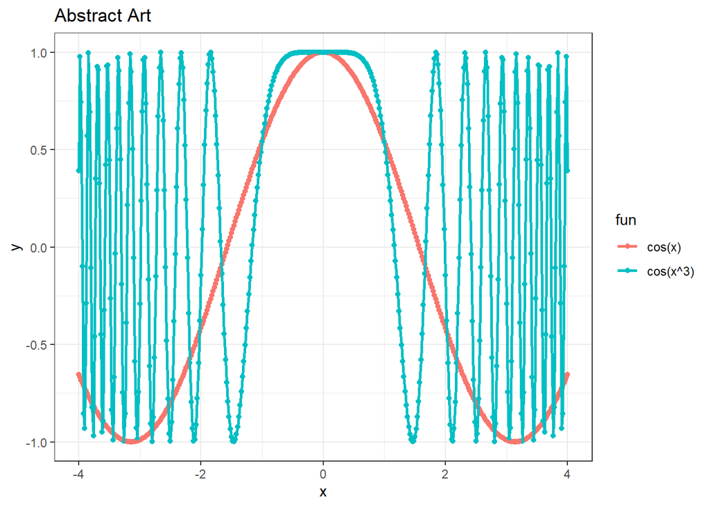

**Problem 4.**

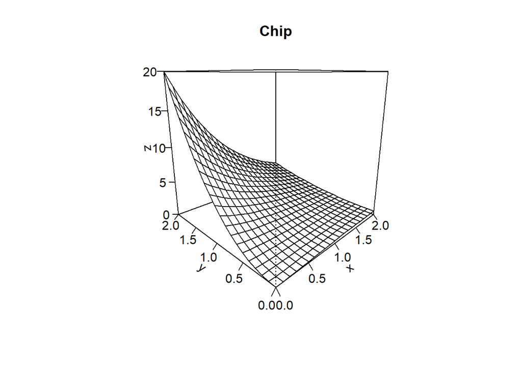

```r
rm(list = ls())

## a.

func_xy <- function(x,y) {

  (x^2 + (5 * y^2)) * exp(-x)

}

## b.

x <- seq(from = 0, to = 2, by = .1)
y <- seq(from = 0, to = 2, by = .1)
z <- outer(X = x, Y = y, FUN = func_xy)

## c.

persp(x, y, z,
      theta = -45,
      phi = 15,
      ticktype="detailed",
      xlab = NULL,
      ylab = NULL,
      zlab = NULL,
      main = "Chip")
```

**Problem 5.**

```r
rm(list = ls())

## a.

func_x <- function(x) {

  exp(-3*x) +  2*x^2 - 5*x + 2

}

## b.

func_x(x = c(9.8, 7.2, 1025))
```

```
## [1]     145.08      69.68 2096127.00
```

```r
## c.

func_xy <- function(x,y) {

  (x^2 + (5 * y^2)) * exp(-x)

}

## d.

func_xy(x = c(10, 43, -3), y = c(34, 690, -45))
```

```
## [1] 2.669516e-01 5.038980e-13 2.035468e+05
```

**Problem 6.**

```r
rm(list = ls())

## a.

# First define our utility funciton

cobb_douglas  <- function(x,y) {

  x^.3*y^.7

}

# Now define a U-max problem

Umax <- function(x1) {

  # x cannot be less than 0 or cost more than our whole budget
  x <- min(max(x1,0), m/px)

  # y is purchased with remainder of budget
  y <- (m - px*x)/py

  # display the quantity of x,y chosen
  print(paste0("x:", x, " y:", y))

  # optim() minimizes so define function as negative
  -cobb_douglas(x,y)

}

# define prices and income
px <- 2
py <- 5
m  <- 100

#optimize
optim(par = 1, fn = Umax, method = "BFGS")
```

```
## [1] "x:1 y:19.6"
## [1] "x:1.001 y:19.5996"
## [1] "x:0.999 y:19.6004"
## [1] "x:3.29356629748434 y:18.6825734810063"
## [1] "x:3.29456629748434 y:18.6821734810063"
## [1] "x:3.29256629748434 y:18.6829734810063"
## [1] "x:4.63065782487879 y:18.1477368700485"
## [1] "x:4.63165782487879 y:18.1473368700485"
## [1] "x:4.62965782487879 y:18.1481368700485"
## [1] "x:7.80964966443945 y:16.8761401342242"
## [1] "x:7.81064966443945 y:16.8757401342242"
## [1] "x:7.80864966443945 y:16.8765401342242"
## [1] "x:8.10192086394759 y:16.759231654421"
## [1] "x:8.10292086394759 y:16.758831654421"
## [1] "x:8.10092086394759 y:16.759631654421"
```

[output cut: 16 more lines]

```
## $par
## [1] 14.99917
##
## $value
## [1] -14.29279
##
## $counts
## function gradient
##       11       10
##
## $convergence
## [1] 0
##
## $message
## NULL
```

Consumer bundle: (x = 15, y = 14)  
Utility level: 14.29

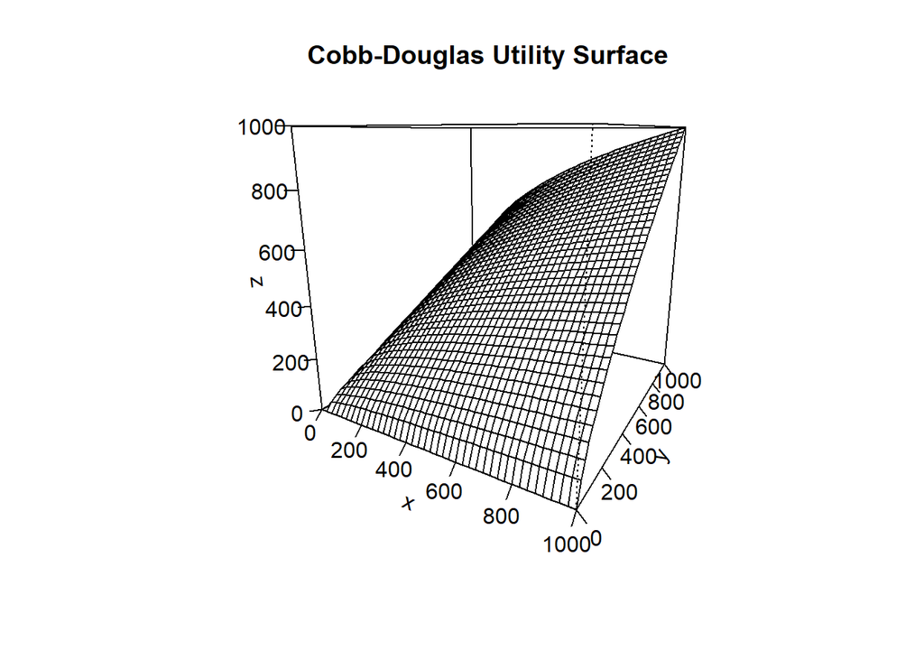

```r
## b.

x <- seq(from = 0, to = 1000, by = 25)
y <- seq(from = 0, to = 1000, by = 25)
z <- outer(X = x, Y = y, FUN = cobb_douglas)

persp(x, y, z,
      theta = 30,
      phi = 15,
      ticktype="detailed",
      xlab = NULL,
      ylab = NULL,
      zlab = NULL,
      main = "Cobb-Douglas Utility Surface")
```

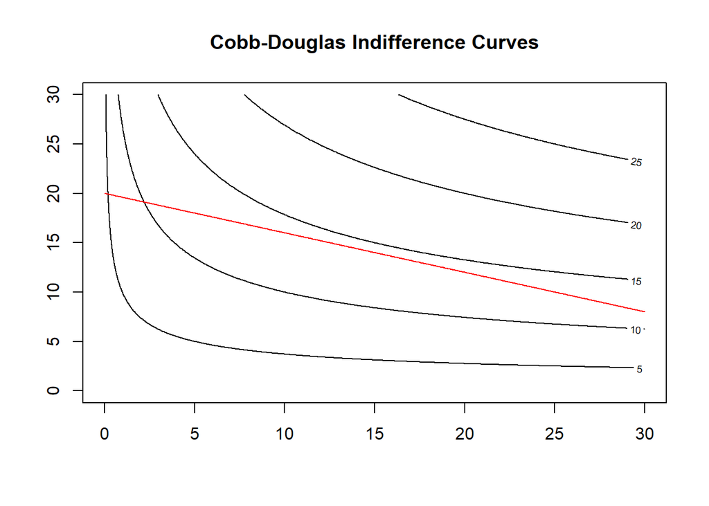

```r
## c.

x <- seq(from = 0, to = 30, by = .05)
y <- seq(from = 0, to = 30, by = .05)
z <- outer(X = x, Y = y, FUN = cobb_douglas)
y1 <- (100 - 2*x)/5

contour(x, y, z,
        nlevels = 10,
        main = "Cobb-Douglas Indifference Curves")

lines(x, y1,
      col = "red")
```

## Part 2: Linear Programming Problem

**Problem 1.**

$$\begin{align} & \underset{x_1,x_2}{\text{Max}} & & \pi = 40x_1 + 45x_2
& & \text{s.t.}
& & \begin{array}{cc}
x_1 + x_2 \leq 600 \\
x_1 \geq 0 \\
x_2 \geq 0 \end{array}
\end{align}$$

Without more constraints, the producer would plant 600 acres of hemp ($x_2$) because it generates more profit per acre than corn ($x_1$).

**Problem 2.**

$$\begin{align} & \underset{x_1,x_2}{\text{Max}} & & \pi = 40x_1 + 45x_2
& & \text{s.t.}
& & \begin{array}{cc}
x_1 + x_2 \leq 600 \\
x_1 + 1.5x_2 \leq 750 \\
x_2 \leq 400 \\
x_1 \geq 0 \\
x_2 \geq 0 \end{array}
\end{align}$$

**Problem 3.**

$$\begin{align}
\underbrace{\underset{x_1,x_2}{\text{Max}}}_\text{D.V.} & &
\underbrace{\left[\begin{array}{cc}
40 & 45
\end{array}\right]
\left[\begin{array}{cc}
x_1 \\
x_2
\end{array}\right]}_\text{Objective Function}
& & \text{s.t.} & &
\underbrace{\left[\begin{array}{cc}
-1 & 0 \\
0 & -1 \\
0 & 1 \\
1 & 1.5 \\
1 & 1
\end{array}\right]
\left[\begin{array}{cc}
x_1 \\
x_2
\end{array}\right] \leq
\left[\begin{array}{cc}
0 \\
0 \\
400 \\
750 \\
600
\end{array}\right]}_\text{Constraints}
\end{align}$$

**Problem 4.**

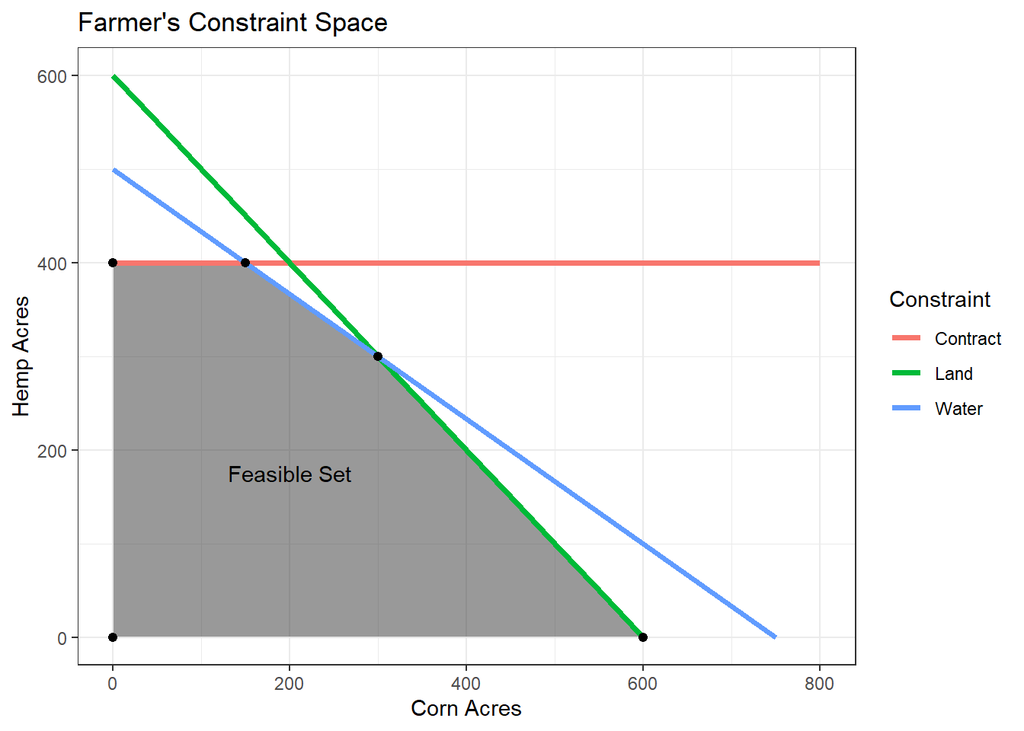

```r
rm(list = ls())


acres <- seq(from = 0, to = 800, by = 50)
hemp_contract <- acres*0 + 400
land <- 600 - acres
water <- (750 - acres)/1.5

constraints <- as.data.frame( matrix(NA, nrow = 51, ncol = 3))
names(constraints) <- c("Constraint", "Acres1", "Acres2")

constraints$Acres1 <- acres
constraints$Acres2 <- c(hemp_contract, land, water)
constraints$Constraint <- c( rep("Contract", 17),
                             rep("Land", 17),
                             rep("Water", 17))

extreme_points <- matrix(c(0, 0,
                           0, 400,
                           150, 400,
                           300, 300,
                           600, 0),
                         ncol = 2, byrow = TRUE)

ggplot() +
  geom_polygon(aes(x = extreme_points[,1],
                   y = extreme_points[,2]),
               color = "grey90",
               alpha = .5) +
  geom_line(data = constraints,
            aes(x = Acres1,
                y = Acres2,
                color = Constraint),
            size = 1.25) +
  geom_point(aes(x = extreme_points[,1],
                 y = extreme_points[,2]),
             size = 1.75) +
  geom_text(aes(x = 200,
                y = 175,
                label = "Feasible Set")) +
  scale_x_continuous(limits = c(0,800)) +
  scale_y_continuous(limits = c(0,600)) +
  labs(title = "Farmer's Constraint Space",
       x = "Corn Acres",
       y = "Hemp Acres") +
  theme_bw()
```

There are five extreme points:  
(0,0) (0,400) (150,400) (300,300) (600,0)

**Problem 5.**

Profit at extreme points:  
(0,0) = $0  
(0,400) = $18,000  
(150,400) = $24,000  
(300,300) = $25,500  
(600,0) = $24,000

Only the land and water constraints bind at the optimal solution: (300,300).

**Problem 6.**

```r
rm(list = ls())

A <- matrix(c(-1, 0,
              0, -1,
              0, 1,
              1, 1.5,
              1, 1),
            ncol = 2,
            byrow = TRUE)

b <- c(0, 0, 400, 750, 600)

obj <- c(40, 45)

farmer <- lp(direction = "max",
             objective.in = obj,
             const.mat = A,
             const.dir = rep("<=", 5),
             const.rhs = b,
             compute.sens = TRUE)

farmer$solution
```

```
## [1] 300 300
```

```r
farmer$objval
```

```
## [1] 25500
```

**Problem 7.**

$800 revenue per acre / 180 bushels per acre = $4.44 price per bushel

**Problem 8.**

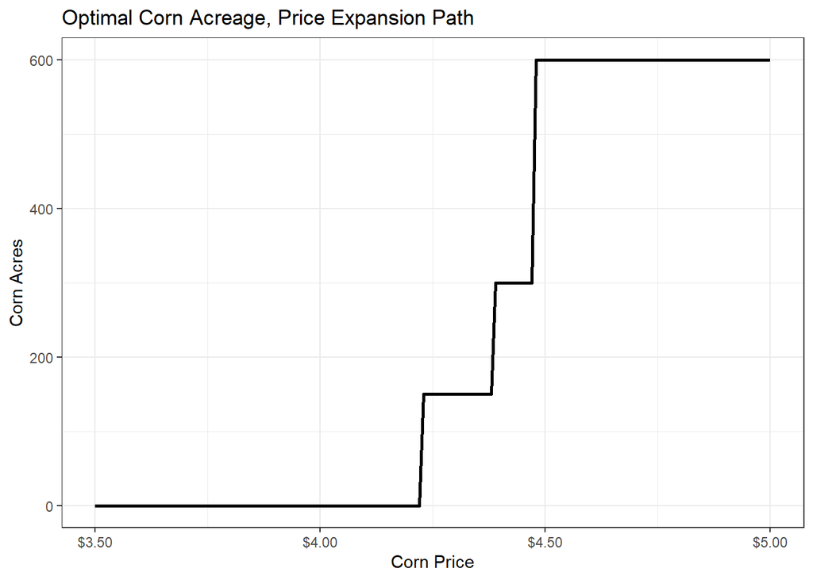

```r
rm(list = ls())

A <- matrix(c(-1, 0,
              0, -1,
              0, 1,
              1, 1.5,
              1, 1),
            ncol = 2,
            byrow = TRUE)

b <- c(0, 0, 400, 750, 600)

cp <- seq(3.5, 5, by = .01)

solutions <- list()

for (i in cp) {

  obj <- c(180*i - 760, 45)

  farmer <- lp(direction = "max",
               objective.in = obj,
               const.mat = A,
               const.dir = rep("<=", 5),
               const.rhs = b,
               compute.sens = TRUE)

  solution <- as.data.frame(cbind(t(farmer$solution), farmer$objval, i))

  solutions[[length(solutions)+1]] <- solution

}

solutions <- do.call(rbind, solutions)


names(solutions) <- c("corn_acres", "hemp_acres", "profit", "corn_price")


ggplot(data = solutions, aes(x = corn_price, y = corn_acres)) +
  geom_line(size = 1) +
  scale_x_continuous(labels = dollar) +
  scale_y_continuous(labels = comma) +
  labs(title = "Optimal Corn Acreage, Price Expansion Path",
        x = "Corn Price",
        y = "Corn Acres") +
  theme_bw()
```

**Problem 9.**

The curve represents how optimal corn production changes relative to corn price changes. The jumps between the plateaus correspond to corn prices that trigger movement to a new extreme point where MR = MC.

**Problem 10.**

```r
A <- matrix(c(-1, 0,
              0, -1,
              0, 1,
              1, 1.5,
              1, 1),
            ncol = 2,
            byrow = TRUE)

b1 <- c(0, 0, 400, 750, 600)
b2 <- c(0, 0, 400, 750, 601)

obj <- c(40, 45)

farmer1 <- lp(direction = "max",
             objective.in = obj,
             const.mat = A,
             const.dir = rep("<=", 5),
             const.rhs = b1,
             compute.sens = TRUE)

farmer2 <- lp(direction = "max",
              objective.in = obj,
              const.mat = A,
              const.dir = rep("<=", 5),
              const.rhs = b2,
              compute.sens = TRUE)

farmer2$objval - farmer1$objval
```

```
## [1] 30
```

Producer WTP for 1 more acre = $30